# Actividad1.7

Cesar Vazquez

2022-11-14

### Dependencias utilizadas

```r
library(stats)
library(factoextra)
```

```r
library(ggplot2)
library(FactoMineR)
```

```r
x = read.csv("paises_mundo.csv")
names(x)
```

```
##  [1] "CrecPobl"    "MortInf"     "PorcMujeres" "PNB95"       "ProdElec"
##  [6] "LinTelf"     "ConsAgua"    "PropBosq"    "PropDefor"   "ConsEner"
## [11] "EmisCO2"
```

## Parte 1

1. Calcule las matrices de varianza-covarianza S con cov(X) y la matriz de correlaciones con cor(X)

```r
covarianza = cov(x)
covarianza
```

```
##                  CrecPobl       MortInf   PorcMujeres         PNB95
## CrecPobl     1.538298e+00  2.195026e+01 -6.078026e+00 -8.933379e+04
## MortInf      2.195026e+01  1.032859e+03 -9.249342e+00 -2.269332e+06
## PorcMujeres -6.078026e+00 -9.249342e+00  7.698322e+01  2.813114e+05
## PNB95       -8.933379e+04 -2.269332e+06  2.813114e+05  4.999786e+10
## ProdElec    -4.973964e+04 -1.043435e+06  2.260248e+05  2.247791e+10
## LinTelf     -1.369079e+02 -4.381366e+03  4.499750e+02  2.039550e+07
## ConsAgua    -4.827092e+01 -1.288211e+03 -1.568313e+03  1.097481e+07
## PropBosq    -3.887018e+00 -1.466316e+01  6.517895e+01  2.474311e+05
## PropDefor    3.361974e-01  1.276296e+01  2.680592e-01 -5.806203e+04
## ConsEner    -8.384169e+02 -4.442568e+04  2.855207e+02  1.415628e+08
## EmisCO2     -1.137877e+00 -9.485500e+01 -2.150132e+00  2.501673e+05
##                  ProdElec       LinTelf      ConsAgua      PropBosq
## CrecPobl    -4.973964e+04 -1.369079e+02 -4.827092e+01     -3.887018
## MortInf     -1.043435e+06 -4.381366e+03 -1.288211e+03    -14.663158
## PorcMujeres  2.260248e+05  4.499750e+02 -1.568313e+03     65.178947
## PNB95        2.247791e+10  2.039550e+07  1.097481e+07 247431.122807
## ProdElec     1.821909e+10  7.583050e+06  1.399817e+07  70359.785965
## LinTelf      7.583050e+06  3.841247e+04  1.193110e+04    248.715789
## ConsAgua     1.399817e+07  1.193110e+04  3.301981e+05  -2220.757895
## PropBosq     7.035979e+04  2.487158e+02 -2.220758e+03    401.003509
## PropDefor   -3.180340e+04 -9.940461e+01 -6.743793e+01      2.625263
## ConsEner     6.801296e+07  3.426262e+05  2.092242e+05  -5153.438596
## EmisCO2      1.392779e+05  6.385700e+02  4.869328e+02    -12.897193
##                 PropDefor      ConsEner       EmisCO2
## CrecPobl     3.361974e-01 -8.384169e+02     -1.137877
## MortInf      1.276296e+01 -4.442568e+04    -94.855000
## PorcMujeres  2.680592e-01  2.855207e+02     -2.150132
## PNB95       -5.806203e+04  1.415628e+08 250167.323509
## ProdElec    -3.180340e+04  6.801296e+07 139277.888640
## LinTelf     -9.940461e+01  3.426262e+05    638.570000
## ConsAgua    -6.743793e+01  2.092242e+05    486.932763
## PropBosq     2.625263e+00 -5.153439e+03    -12.897193
## PropDefor    1.817253e+00 -1.051522e+03     -2.632487
## ConsEner    -1.051522e+03  5.014395e+06  10286.159781
## EmisCO2     -2.632487e+00  1.028616e+04     27.268614
```

```r
correlacion = cor(x)
correlacion
```

```
##                CrecPobl     MortInf PorcMujeres       PNB95    ProdElec
## CrecPobl     1.00000000  0.55067948 -0.55852711 -0.32212154 -0.29711119
## MortInf      0.55067948  1.00000000 -0.03280139 -0.31579250 -0.24053689
## PorcMujeres -0.55852711 -0.03280139  1.00000000  0.14338826  0.19085114
## PNB95       -0.32212154 -0.31579250  0.14338826  1.00000000  0.74476081
## ProdElec    -0.29711119 -0.24053689  0.19085114  0.74476081  1.00000000
## LinTelf     -0.56321228 -0.69558922  0.26167018  0.46539599  0.28664508
## ConsAgua    -0.06772953 -0.06975563 -0.31106243  0.08541500  0.18047653
## PropBosq    -0.15650281 -0.02278415  0.37096694  0.05525919  0.02603078
## PropDefor    0.20107881  0.29459348  0.02266339 -0.19262327 -0.17478434
## ConsEner    -0.30187731 -0.61731132  0.01453216  0.28272492  0.22501894
## EmisCO2     -0.17568860 -0.56520778 -0.04692837  0.21425123  0.19760017
##                 LinTelf    ConsAgua    PropBosq   PropDefor    ConsEner
## CrecPobl    -0.56321228 -0.06772953 -0.15650281  0.20107881 -0.30187731
## MortInf     -0.69558922 -0.06975563 -0.02278415  0.29459348 -0.61731132
## PorcMujeres  0.26167018 -0.31106243  0.37096694  0.02266339  0.01453216
## PNB95        0.46539599  0.08541500  0.05525919 -0.19262327  0.28272492
## ProdElec     0.28664508  0.18047653  0.02603078 -0.17478434  0.22501894
## LinTelf      1.00000000  0.10593934  0.06337138 -0.37623801  0.78068385
## ConsAgua     0.10593934  1.00000000 -0.19299225 -0.08705811  0.16259804
## PropBosq     0.06337138 -0.19299225  1.00000000  0.09725032 -0.11492480
## PropDefor   -0.37623801 -0.08705811  0.09725032  1.00000000 -0.34833836
## ConsEner     0.78068385  0.16259804 -0.11492480 -0.34833836  1.00000000
## EmisCO2      0.62393719  0.16227447 -0.12333592 -0.37396154  0.87965517
##                 EmisCO2
## CrecPobl    -0.17568860
## MortInf     -0.56520778
## PorcMujeres -0.04692837
## PNB95        0.21425123
## ProdElec     0.19760017
## LinTelf      0.62393719
## ConsAgua     0.16227447
## PropBosq    -0.12333592
## PropDefor   -0.37396154
## ConsEner     0.87965517
## EmisCO2      1.00000000
```

2. Calcule los valores y vectores propios de cada matriz.La función en R es: eigen().

```r
eigen(covarianza)
```

```
## eigen() decomposition
## $values
##  [1] 6.163576e+10 6.581612e+09 4.636256e+06 3.107232e+05 1.216015e+04
##  [6] 5.137767e+02 3.627885e+02 4.542082e+01 5.800868e+00 1.438020e+00
## [11] 4.768083e-01
##
## $vectors
##                [,1]          [,2]          [,3]          [,4]          [,5]
##  [1,] -1.658168e-06  4.706785e-07  0.0001263736 -1.928408e-05 -0.0055373971
##  [2,] -4.048139e-05 -1.774254e-05  0.0082253821 -2.493257e-03 -0.0944030203
##  [3,]  5.739096e-06 -1.084543e-05  0.0001318149  5.538307e-03  0.0314036410
##  [4,]  8.880376e-01  4.597632e-01  0.0026022071 -3.893588e-04 -0.0003327409
##  [5,]  4.597636e-01 -8.880405e-01  0.0005694896  1.096305e-03  0.0002207819
##  [6,]  3.504341e-04  4.016179e-04 -0.0619424889  7.641174e-03  0.9921404486
##  [7,]  2.625508e-04 -1.122118e-03 -0.0401453227 -9.991411e-01  0.0057795144
```

[output cut: 28 more lines]

```r
eigen(correlacion)
```

```
## eigen() decomposition
## $values
##  [1] 4.02987902 1.92999195 1.37041115 0.86451597 0.79414057 0.72919997
##  [7] 0.57130511 0.32680096 0.16806846 0.14632819 0.06935866
##
## $vectors
##               [,1]        [,2]        [,3]        [,4]        [,5]        [,6]
##  [1,] -0.314119414  0.34835747 -0.07352541  0.44028717  0.32972147 -0.18392437
##  [2,] -0.392395442 -0.04136238 -0.17759254  0.13398483 -0.08340489 -0.08656390
##  [3,]  0.116546319 -0.58283641  0.16686305 -0.05865031 -0.18654100  0.16835650
##  [4,]  0.295393771 -0.17690839 -0.53343025  0.26248209  0.14110658  0.04653378
##  [5,]  0.258964724 -0.17356372 -0.61438847  0.17389644  0.07521971  0.02821905
##  [6,]  0.446082934 -0.02719077  0.15177250 -0.04959796  0.05416498  0.02442175
##  [7,]  0.092410503  0.32060987 -0.37024258 -0.73603097 -0.02671021 -0.30940890
##  [8,]  0.005692925 -0.45742697  0.16480339 -0.04024882  0.41531702 -0.75356463
##  [9,] -0.243652293 -0.15408201 -0.02961449 -0.33650345  0.73261463  0.50894232
## [10,]  0.415029554  0.23286257  0.20608749  0.06730166  0.23100421  0.05806466
## [11,]  0.374531032  0.29168698  0.20631751  0.14843513  0.24028756 -0.02809233
##                [,7]        [,8]        [,9]       [,10]       [,11]
##  [1,]  0.1628974320 -0.09481963  0.52181220  0.34674573 -0.10062784
##  [2,]  0.6398040762 -0.32307802 -0.29031618 -0.38959240  0.17487096
##  [3,]  0.5310867107  0.05209889  0.23599758  0.42854658 -0.16786800
##  [4,] -0.1490207046 -0.44913216 -0.36995675  0.34911534 -0.15247432
##  [5,]  0.1082745817  0.50343911  0.30681318 -0.33770404  0.12366382
##  [6,] -0.0008501608 -0.56975094  0.44733110 -0.20997673  0.44992596
##  [7,]  0.2357666690 -0.05962470  0.08358225  0.20561803 -0.07067780
##  [8,] -0.0806036686  0.04275404 -0.07438520 -0.08671232 -0.01493710
##  [9,]  0.0112333588 -0.01607505 -0.01868615 -0.03209758  0.07259619
## [10,]  0.2711228006 -0.05023582 -0.04339752 -0.36147417 -0.67912543
## [11,]  0.3352822144  0.30978009 -0.37666244  0.28779437  0.46737561
```

3. Calcule la proporción de varianza explicada por cada componente.

Se sugiere dividir cada lambda entre la varianza total (las lambdas están en eigen(S)[1]). La varianza total es la suma de las varianzas de la diagonal de S. Una forma es sum(diag(S)). La varianza total de los componentes es la suma de los valores propios (es decir, la suma de la varianza de cada componente), sin embargo, si sumas la diagonal de S (es decir, la varianza de cada x), te da el mismo valor (¡comprúebalo!). Recuerda que las combinaciones lineales buscan reproducir la varianza de X.

```r
lambda = eigen(covarianza)[1]
var_total = sum(diag(covarianza))
xVar = lambda$values/var_total
xVar
```

```
##  [1] 9.034543e-01 9.647298e-02 6.795804e-05 4.554567e-06 1.782429e-07
##  [6] 7.530917e-09 5.317738e-09 6.657763e-10 8.502887e-11 2.107843e-11
## [11] 6.989035e-12
```

4. Acumule los resultados anteriores. (cumsum() puede servirle).

```r
cumsum(xVar)
```

```
##  [1] 0.9034543 0.9999273 0.9999953 0.9999998 1.0000000 1.0000000 1.0000000
##  [8] 1.0000000 1.0000000 1.0000000 1.0000000
```

5. Según los resultados anteriores, ¿qué componentes son los más importantes? ¿qué variables son las que más contribuyen a la primera y segunda componentes principales? ¿por qué lo dice? ¿influyen las unidades de las variables?
- Los componentes 1 y 2 son los de mayor importancia, por que explican el 99%.
- Los principales variables que contribuyen con la primer y segundos componentes, son PNB95 y ProdElec. Ya que son los que mayor influyen, por la magnitud de las unidades de sus variables.

```r
prcomp(x)
```

```
## Standard deviations (1, .., p=11):
##  [1] 2.482655e+05 8.112714e+04 2.153197e+03 5.574255e+02 1.102731e+02
##  [6] 2.266664e+01 1.904701e+01 6.739497e+00 2.408499e+00 1.199175e+00
## [11] 6.905131e-01
##
## Rotation (n x k) = (11 x 11):
##                       PC1           PC2           PC3           PC4
## CrecPobl     1.658168e-06  4.706785e-07 -0.0001263736  1.928408e-05
## MortInf      4.048139e-05 -1.774254e-05 -0.0082253821  2.493257e-03
## PorcMujeres -5.739096e-06 -1.084543e-05 -0.0001318149 -5.538307e-03
## PNB95       -8.880376e-01  4.597632e-01 -0.0026022071  3.893588e-04
## ProdElec    -4.597636e-01 -8.880405e-01 -0.0005694896 -1.096305e-03
## LinTelf     -3.504341e-04  4.016179e-04  0.0619424889 -7.641174e-03
## ConsAgua    -2.625508e-04 -1.122118e-03  0.0401453227  9.991411e-01
## PropBosq    -4.089564e-06  7.790843e-06 -0.0012719918 -6.435797e-03
## PropDefor    1.073825e-06  2.350808e-07 -0.0001916177 -4.043796e-05
## ConsEner    -2.547156e-03  7.126782e-04  0.9972315499 -3.973568e-02
## EmisCO2     -4.643724e-06 -1.315731e-06  0.0020679047  5.626049e-05
##                       PC5           PC6           PC7           PC8
## CrecPobl    -0.0055373971  1.243456e-02 -5.359089e-03  8.390810e-02
## MortInf     -0.0944030203  9.917515e-01 -2.258020e-02  7.891128e-02
## PorcMujeres  0.0314036410  8.552992e-02  1.136481e-01 -9.856498e-01
## PNB95       -0.0003327409 -8.621005e-06  7.566477e-06 -1.217248e-05
## ProdElec     0.0002207819  1.955408e-05 -1.544658e-05  2.558998e-05
## LinTelf      0.9921404486  9.109622e-02 -4.748682e-02  3.416812e-02
## ConsAgua     0.0057795144 -1.087229e-03  6.863294e-03 -4.698731e-03
## PropBosq     0.0419331615  1.721948e-02  9.920538e-01  1.169638e-01
## PropDefor   -0.0018090751  1.758667e-03  7.455427e-03 -1.811443e-02
## ConsEner    -0.0625729475  2.639673e-03  3.764707e-03 -1.267052e-03
## EmisCO2     -0.0042367120 -1.877994e-02  1.709137e-03  5.204823e-03
##                       PC9          PC10          PC11
## CrecPobl    -6.778358e-02 -1.158091e-01 -9.872887e-01
## MortInf     -1.637836e-02  4.264872e-04  2.092491e-02
## PorcMujeres -1.468464e-02  8.241465e-03 -8.344324e-02
## PNB95       -3.971469e-07  4.274451e-07 -2.723997e-07
## ProdElec     1.059471e-06 -1.353881e-06  2.086858e-07
## LinTelf     -5.379549e-03 -3.409423e-03 -4.944396e-04
## ConsAgua     7.965261e-05  3.621425e-05 -4.780416e-04
## PropBosq     1.416566e-03  5.891758e-03  3.748977e-03
## PropDefor    1.283039e-01 -9.859317e-01  1.052934e-01
## ConsEner     2.262931e-03  2.672618e-04 -5.906242e-05
## EmisCO2     -9.891529e-01 -1.200519e-01  8.221371e-02
```

6. Hacer los mismos pasos anteriores, pero con la matriz de correlaciones (se obtiene con cor(x) si x está compuesto por variables numéricas)

```r
lambda = eigen(correlacion)[1]
var_total = sum(diag(correlacion))
xVar = lambda$values/var_total
xVar
```

```
##  [1] 0.366352638 0.175453813 0.124582832 0.078592361 0.072194597 0.066290906
##  [7] 0.051936828 0.029709178 0.015278951 0.013302563 0.006305332
```

```r
cumsum(xVar)
```

```
##  [1] 0.3663526 0.5418065 0.6663893 0.7449816 0.8171762 0.8834671 0.9354040
##  [8] 0.9651132 0.9803921 0.9936947 1.0000000
```

7. Compare los resultados de los incisos 6 y 5. ¿qué concluye?

En conclusión la correlación crece de manera más acomulativa pero en los primeros dos componentes se tiene el 54%, a diferencia de las covarianzas que en los segundos componentes se tiene el 99%. Ya que en la matriz de correlación es estandarizada. Entonces nos quedariamos con el segundo modelo por que los datos son más reales, pero el modelo esta muy distribuido entre los componentes, al parecer este modelo tampoco es bueno.

## Parte 2

Obtenga las gráficas de respectivas con S (matriz de varianzas-covarianzas) y con R (matriz de correlaciones) de las dos primeras componentes e interprete los resultados en término de agrupación de variables (puede ayudar “índice de riqueza”, “índice de ruralidad”).

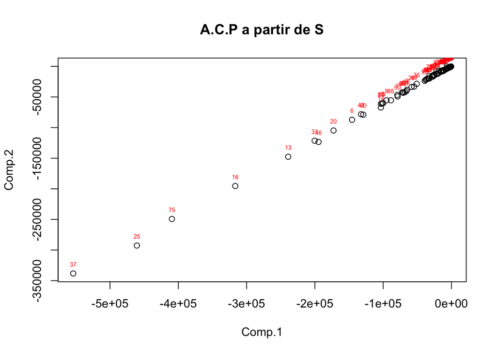

```r
resS=princomp(x, cor=T)
compS=as.matrix(x)%*%resS$loadings
plot(compS[,1:2],type="p", main = "A.C.P a partir de S")
text(compS[,1],compS[,2],1:nrow(compS), cex = 0.5, pos = 3, pch = 19, col = "red")
```

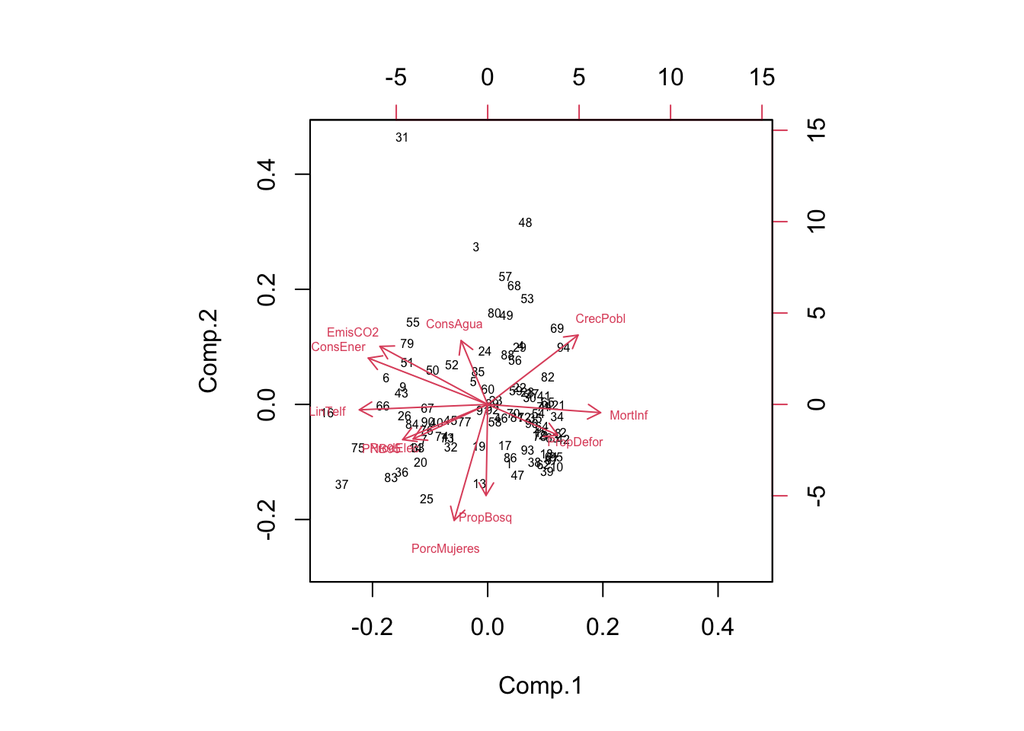

```r
biplot(resS, cex = 0.5)
```

- A simplemente vista podemos observar que el componente 1 no tiene mayor varianza relativa contra el componente 2.
- No hay una contundencia del modelo para nuestras variables esto se comprueba utilizando la matriz de correlación donde no se ven variables significantes, y cuando no se utiliza la correlación podemos observar dos variables que son contundentes pero esto no es verdadero por que la magnitud de esas variables es muy grande.

## Parte 3

Explore los siguientes gráficos relativos al problema y Componentes Principales y dé una interpretación de cada gráfico.

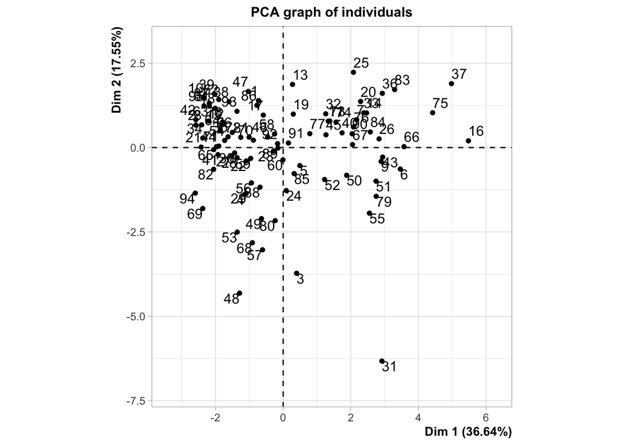

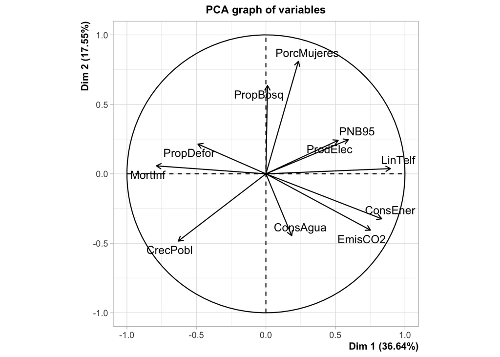

```r
cp3 = PCA(x)
```

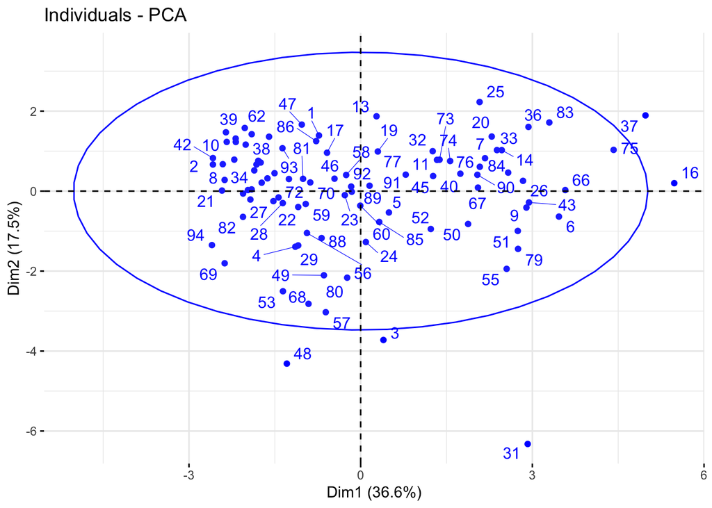

```r
fviz_pca_ind(cp3, col.ind = "blue", addEllipses = TRUE, repel = TRUE)
```

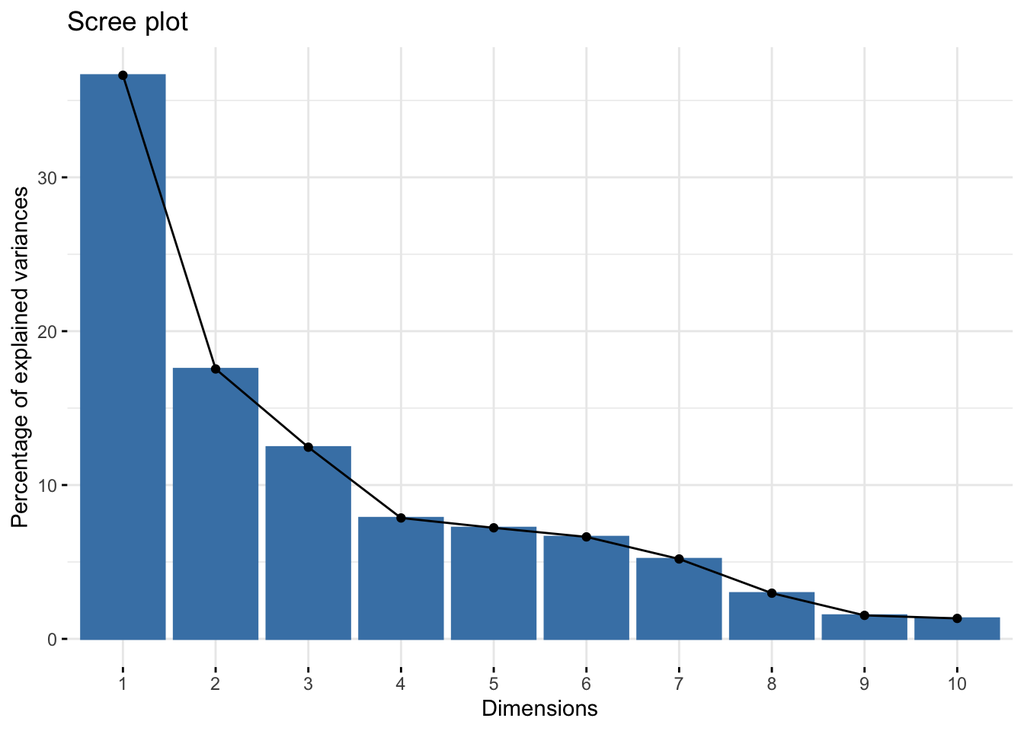

```r
fviz_screeplot(cp3)
```

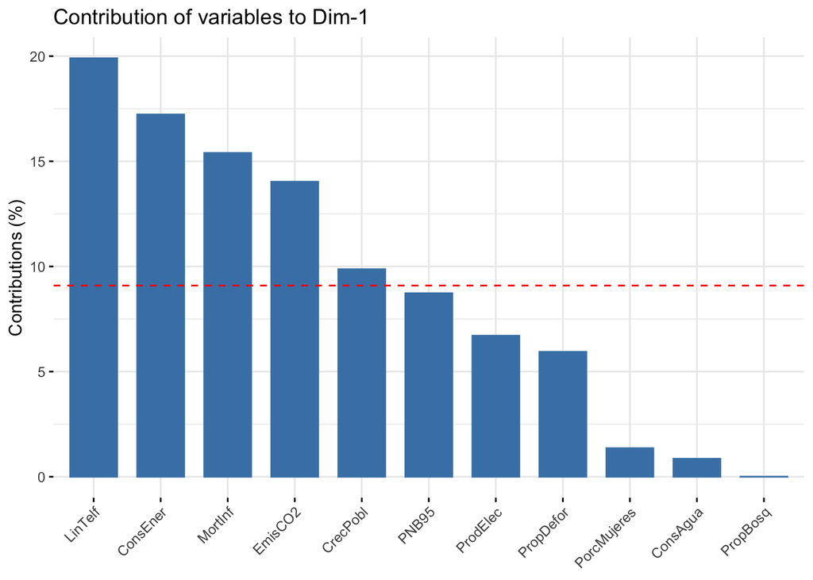

```r
fviz_contrib(cp3, choice = c("var"))
```

- Se observa que los componentes se distribuyen con normalidad y el modelo no es contundente.